# ggplot for R Open Lab

Yue Jin

10/24/2017

## What ggplot2 can do and can not do?

- gg stands for grammar of graphics. ggplot2 is consistent with grammar of graphics.
- ggplot cannot do 3D graphic and interactive graphics. (use plotly along with ggplot)

## Grammar of Graphics

A grammar of graphics provides a structure to combine graphical elements into figures that display data in a meaningful way. Building blocks of a graph include: * data * coordinate system: cartesian, polar * geometric object: marks you used to represent data (points, line, bins) * aesthetic mapping: visual property of the objects in the plot, anything you can see (location, shape, size) * statistical transformations: mean, median

## How does ggplot work?

- Every graph is composed of a data set, a coordinate system and a set of geoms that represent data points
- To display data values, map variables in the data set to aesthetic properties of the geom like size, color, and x and y locations.

## Setup

```r
if(!require("ggplot2")){
  install.packages("ggplot2")
}
if(!require("ggthemes")){
  install.packages("ggthemes")
}
library(ggplot2)
library(ggthemes)
```

## Example1

We would like to plot carat vs price in the diamonds dataset. No transformation is needed. We would liek to pepresent it by points

### Recall:

- geom is a geometrical object used to represent data in a plot: points, lines, bins
- aes is the visual property of the objects in the plot. i.e. something you can see, examples: position, shape, size, color etc

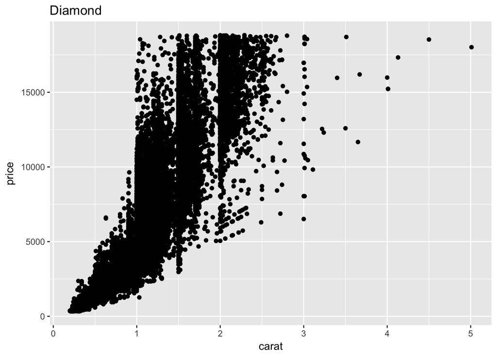

```r
a<-ggplot(diamonds, aes(x=carat, y=price))+
    geom_point()+
    ggtitle("Diamond")
a
```

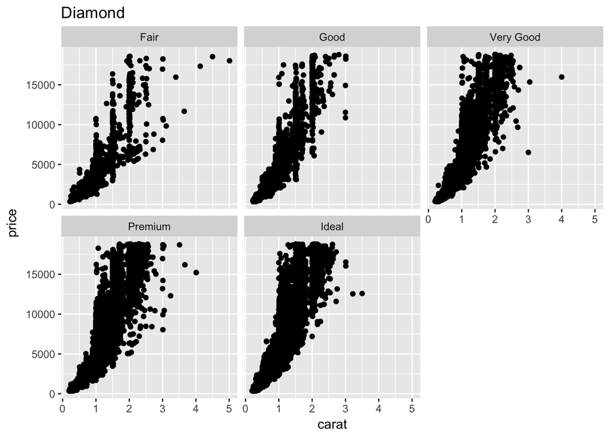

```r
b<-a + facet_wrap(~cut)
b
```

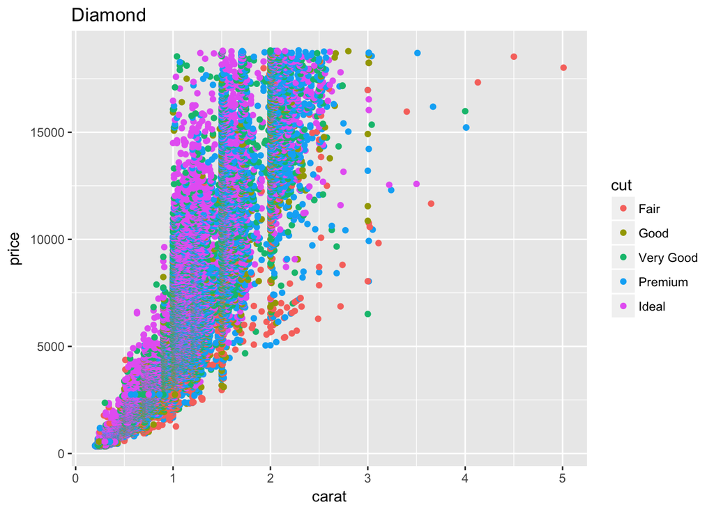

```r
c<-ggplot(diamonds)+
    geom_point(aes(x=carat, y=price,color=cut))+
    ggtitle("Diamond")
c
```

Personalize your plot

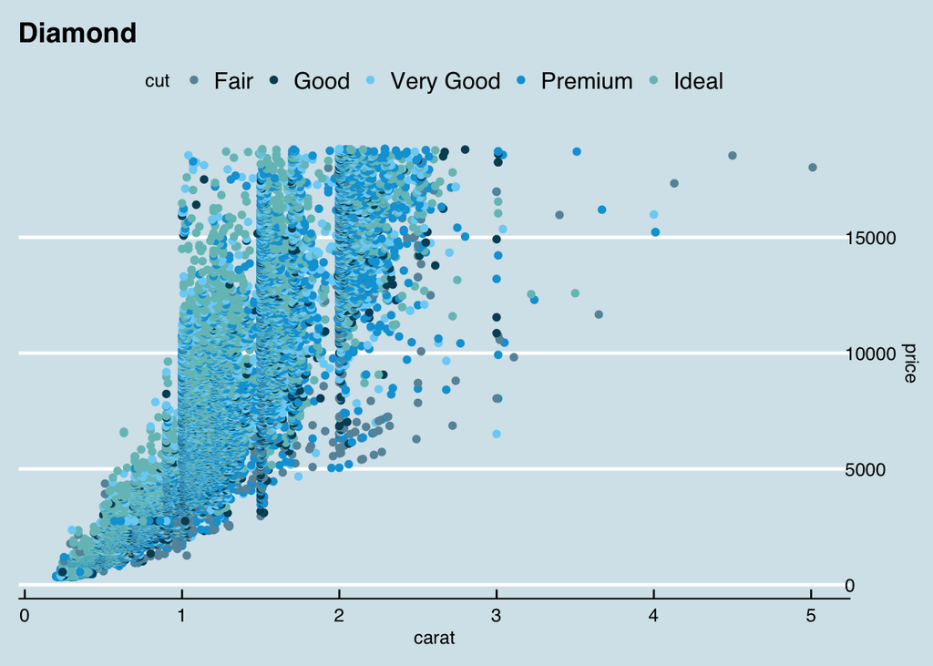

```r
d<-c+theme_economist() + scale_colour_economist() +
  scale_y_continuous(position = "right")
d
```

Add another layer of our prediction/calculated statistics

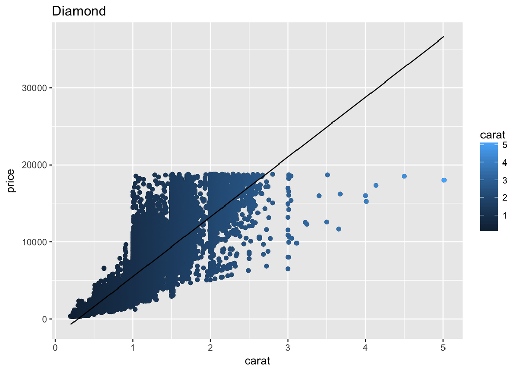

```r
pred <- predict(lm(price ~ carat, data = diamonds))
e<-a +
  geom_point(aes(colour = carat)) +
  geom_line(aes(y=pred))
e
```

Our prediction doesn’t look good. To better see the pattern of the data, we can use geom_smooth By default, the ggplot chooses a method to fit the data based on the size of the data and then draw 95% confidence level interval for predictions

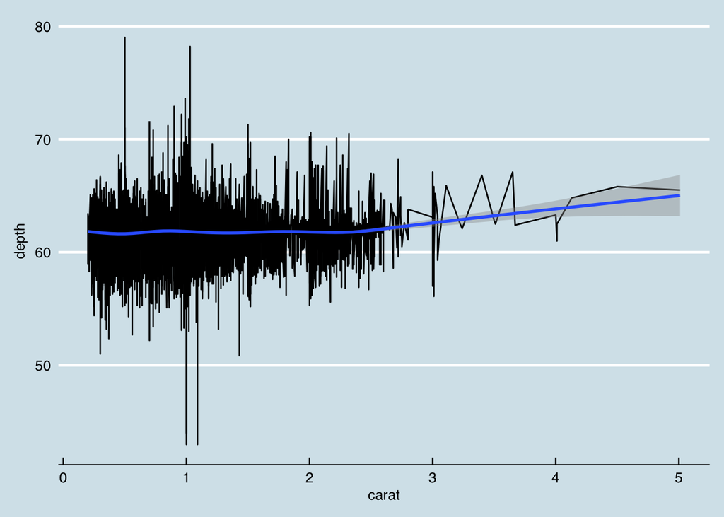

```r
f<-a +
  geom_point(aes(colour = carat)) +
  geom_smooth()+
  theme_economist()

ggplot(diamonds,aes(x=carat, y=depth))+
  geom_line()+
  geom_smooth()+
  theme_economist()
```

## Example 2

Stack bar plot

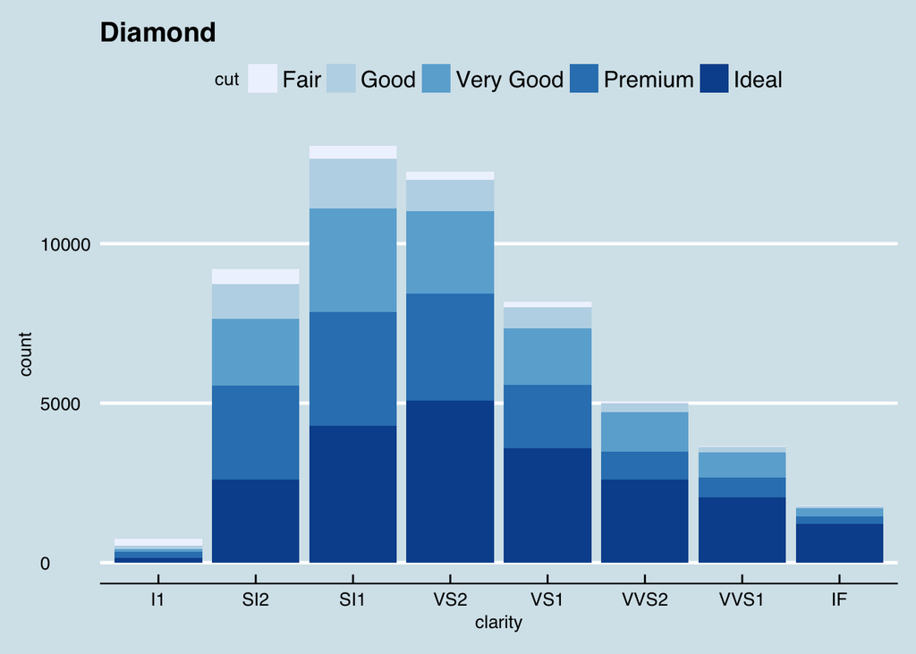

```r
ggplot(diamonds, aes(x = clarity, fill = cut)) +
  geom_bar() +
  scale_fill_brewer() +
  theme_economist()+
  ggtitle("Diamond")
```

## Example 3

Violin Plot

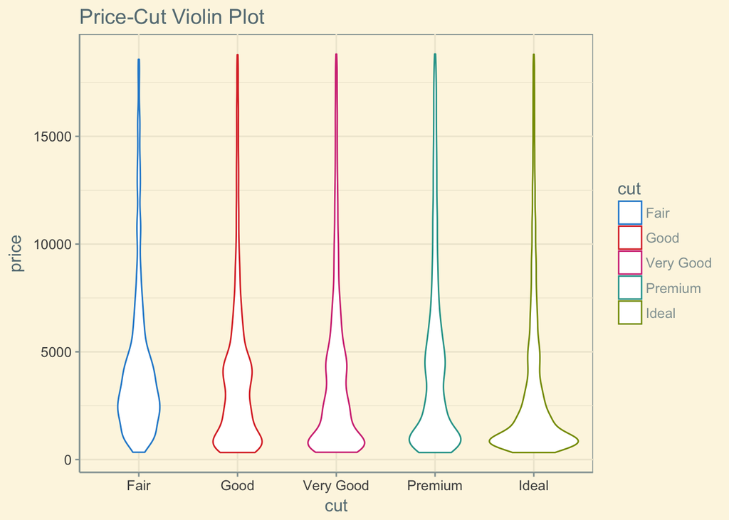

```r
ggplot(diamonds,aes(x=cut,y=price))+
  geom_violin(scale="area",aes(color=cut))+
  theme_solarized() +
  scale_colour_solarized("blue")+
  ggtitle("Price-Cut Violin Plot")
```

## Example 4

Plot two datasets together

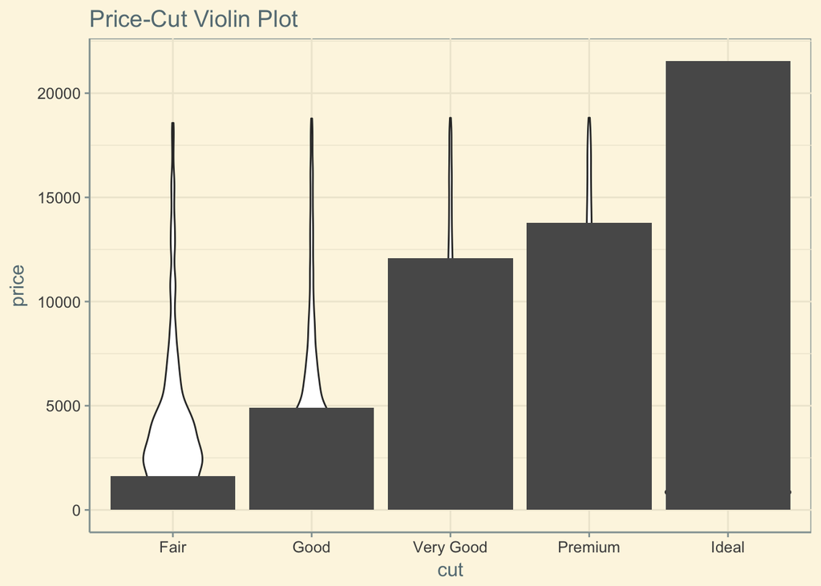

```r
df1<-diamonds[,c("cut","price")]
df2<-diamonds$cut

ggplot()+
  geom_violin(data=df1,aes(x=cut,y=price))+
  geom_bar(data=data.frame(table(df2)),stat="identity",aes(x=df2,y=Freq))+
  theme_solarized() +
  scale_colour_solarized("blue")+
  ggtitle("Price-Cut Violin Plot")
```